# Targeted Hormone Sex Comparison

## Standalone literature panels (right-hand axis)

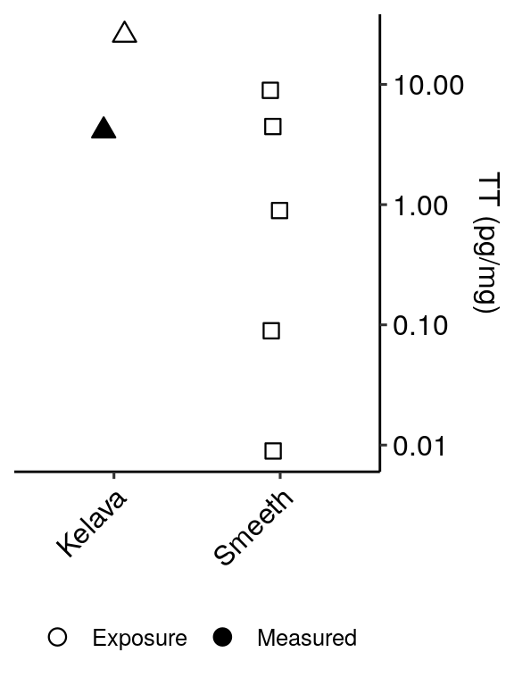

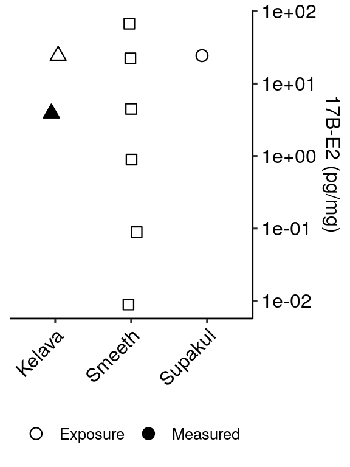

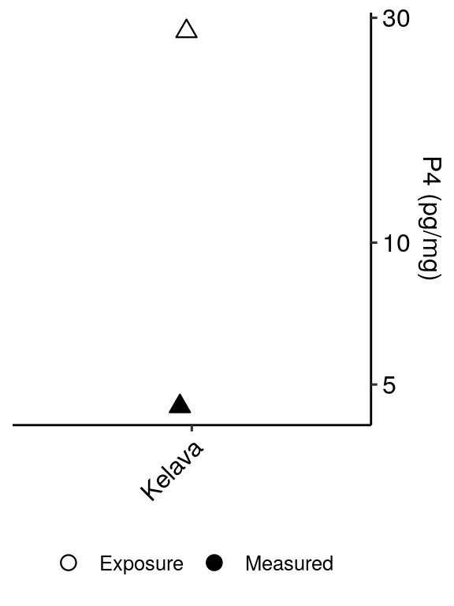

```r
plot_lit_panel <- function(h) {
  d <- dplyr::filter(lit_hormones, hormone == h)
  if (nrow(d) == 0) return(NULL)

  ggplot(d, aes(x = study, y = value)) +
    geom_point(aes(shape = study, fill = type),
               size = 3, stroke = 0.6, colour = "black",
               position = position_jitter(width = 0.08, height = 0)) +
    scale_shape_manual(values = study_shapes, guide = "none") +
    scale_fill_manual(values = type_fills, name = NULL,
                      guide = guide_legend(override.aes = list(shape = 21))) +
    scale_y_log10(position = "right") +
    labs(x = NULL, y = hormone_labels[[h]]) +
    theme_pubr(legend = "bottom") +
    theme(axis.text.x = element_text(angle = 45, hjust = 1))
}

for (h in c("TT", "E2", "P4")) {
  p <- plot_lit_panel(h)
  if (is.null(p)) next
  print(p)
  ggsave(paste0("lit_", tolower(h), "_standalone.svg"),
         plot = p, path = svg_path, width = 3, height = 4)
  ggsave(paste0("lit_", tolower(h), "_standalone.png"),
         plot = p, path = svg_path, width = 3, height = 4, dpi = 300)
}
```

## Combined panels: our distribution with literature overlaid

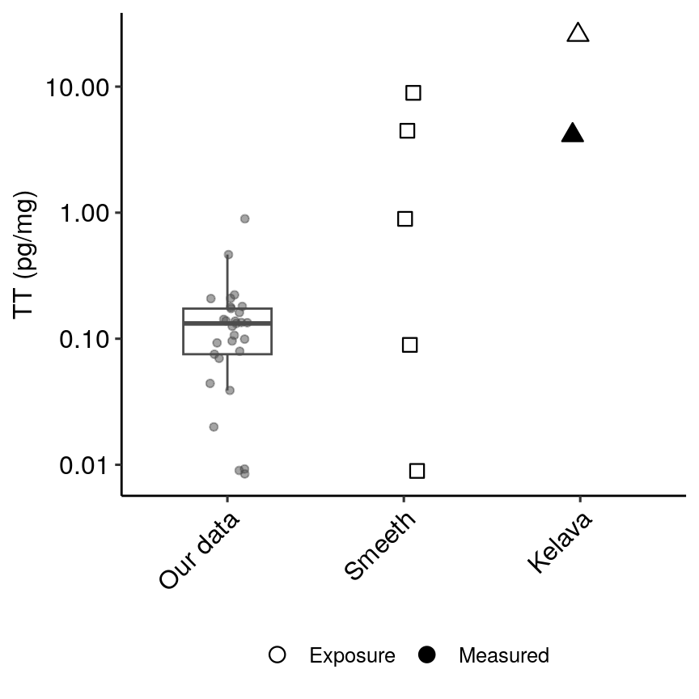

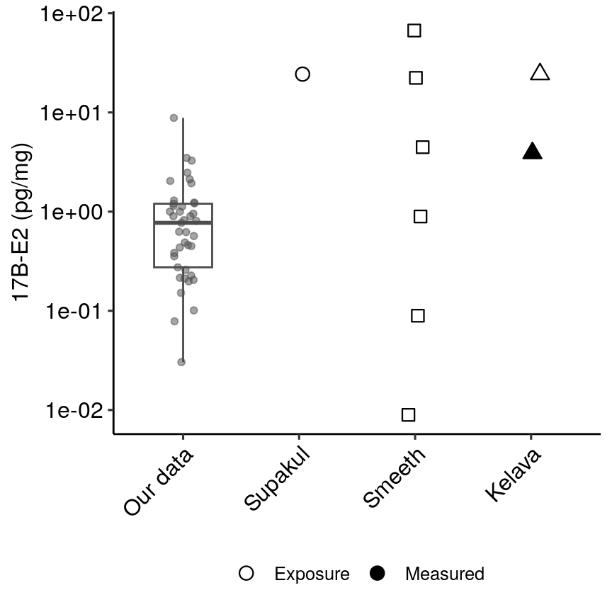

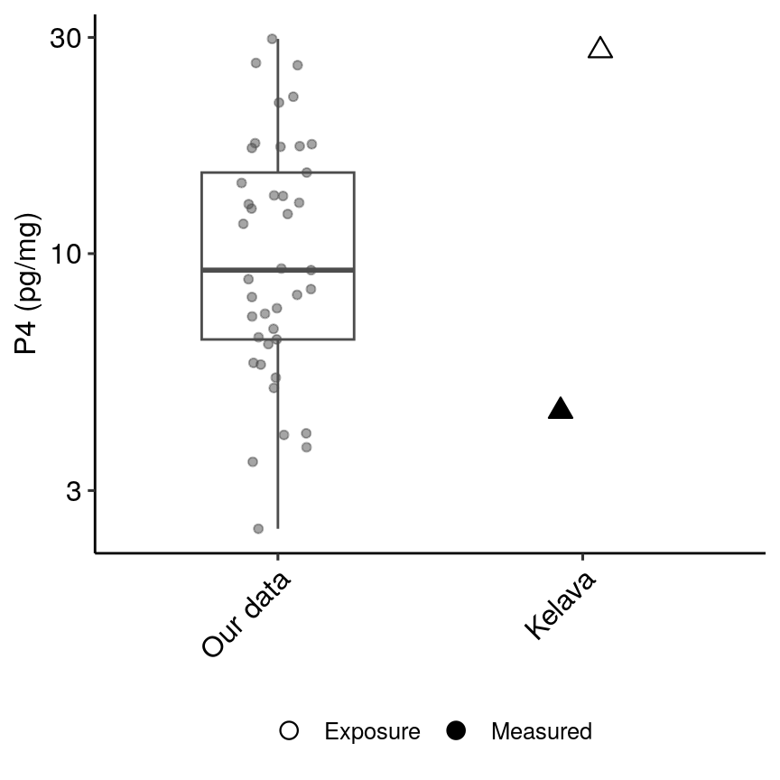

```r
plot_lit_combined <- function(h) {
  d_ours <- dplyr::filter(our_hormones_log, hormone == h)
  d_lit  <- dplyr::filter(lit_hormones, hormone == h)

  ggplot() +
    geom_boxplot(data = d_ours, aes(x = "Our data", y = value),
                 width = 0.5, outlier.shape = NA, colour = "grey30") +
    geom_jitter(data = d_ours, aes(x = "Our data", y = value),
                width = 0.12, height = 0, alpha = 0.5, size = 1.4,
                colour = "grey30") +
    geom_point(data = d_lit, aes(x = study, y = value,
                                 shape = study, fill = type),
               size = 3, stroke = 0.6, colour = "black",
               position = position_jitter(width = 0.08, height = 0)) +
    scale_x_discrete(limits = c("Our data",
                                intersect(c("Supakul", "Smeeth", "Kelava"),
                                          unique(d_lit$study)))) +
    scale_shape_manual(values = study_shapes, guide = "none") +
    scale_fill_manual(values = type_fills, name = NULL,
                      guide = guide_legend(override.aes = list(shape = 21))) +
    scale_y_log10() +
    labs(x = NULL, y = hormone_labels[[h]]) +
    theme_pubr(legend = "bottom") +
    theme(axis.text.x = element_text(angle = 45, hjust = 1))
}

combined_plots <- purrr::map(c("TT", "E2", "P4"), plot_lit_combined)
names(combined_plots) <- c("TT", "E2", "P4")

for (h in names(combined_plots)) {
  print(combined_plots[[h]])
  ggsave(paste0("lit_", tolower(h), "_combined.svg"),
         plot = combined_plots[[h]], path = svg_path, width = 4.5, height = 4.5)
  ggsave(paste0("lit_", tolower(h), "_combined.png"),
         plot = combined_plots[[h]], path = svg_path, width = 4.5, height = 4.5,
         dpi = 300)
}
```

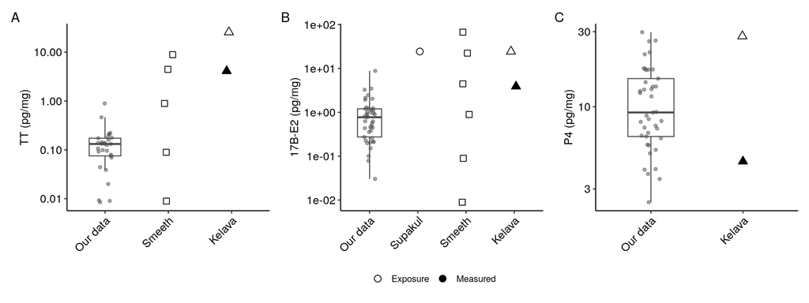

```r
lit_grid <- (combined_plots$TT | combined_plots$E2 | combined_plots$P4) +
  plot_layout(guides = "collect") +
  plot_annotation(tag_levels = "A") &
  theme(legend.position = "bottom")

print(lit_grid)
```

```r
ggsave("lit_all_hormones_combined.svg", plot = lit_grid, path = svg_path,
       width = 12, height = 4.5)
ggsave("lit_all_hormones_combined.png", plot = lit_grid, path = svg_path,
       width = 12, height = 4.5, dpi = 300)
```

# Receptor Kd Reference Lines

Adds horizontal reference lines showing the tissue-equivalent dissociation constant for each hormone’s cognate receptor(s).

Kd values are free-ligand affinities converted to a tissue concentration:

```
Kd (nM) x MW (g/mol) = pg/mL, then / brain density (mg/mL) = pg/mg
```

Note that measured tissue concentrations are *total* (protein-bound plus free plus intracellular), whereas Kd describes free ligand at the receptor. These lines therefore mark a permissive floor, not an occupancy estimate.

```r
# Brain density estimate appropriate to the GW16-24 window (Ultrasound Obstet Gynecol, doi:10.1002/uog.70140).
# Change here to propagate to every panel and to the literature conversions.
BRAIN_DENSITY <- 1120  # mg/mL

kd_receptors <- tribble(
  ~hormone, ~receptor, ~kd_nM, ~mw_g_mol,
  "TT",     "AR",       0.26,   272.4,
  "E2",     "ERa",      0.13,   288.4,
  "E2",     "ERB1",     0.15,   288.4,
  "E2",     "ERB2",     1.84,   288.4,
  "P4",     "PR",       0.38,   314.5
) %>%
  mutate(
    pg_per_mL = kd_nM * mw_g_mol,
    kd_pg_mg  = pg_per_mL / BRAIN_DENSITY,
    hormone   = factor(hormone, levels = c("TT", "E2", "P4")),
    # ERB2 is ~10x weaker than the other estrogen receptors; distinguish it
    linetype  = if_else(receptor == "ERB2", "dotted", "dashed")
  )

kable(
  kd_receptors %>%
    dplyr::select(hormone, receptor, kd_nM, mw_g_mol, pg_per_mL, kd_pg_mg) %>%
    mutate(across(c(pg_per_mL, kd_pg_mg), ~round(.x, 4))),
  caption = paste0("Receptor Kd converted to tissue-equivalent pg/mg ",
                   "(brain density = ", BRAIN_DENSITY, " mg/mL)")
)
```

Receptor Kd converted to tissue-equivalent pg/mg (brain density = 1120 mg/mL)

| hormone | receptor | kd_nM | mw_g_mol | pg_per_mL | kd_pg_mg |
| --- | --- | --- | --- | --- | --- |
| TT | AR | 0.26 | 272.4 | 70.824 | 0.0632 |
| E2 | ERa | 0.13 | 288.4 | 37.492 | 0.0335 |
| E2 | ERB1 | 0.15 | 288.4 | 43.260 | 0.0386 |
| E2 | ERB2 | 1.84 | 288.4 | 530.656 | 0.4738 |
| P4 | PR | 0.38 | 314.5 | 119.510 | 0.1067 |

```r
#' Overlay receptor Kd reference lines on an existing hormone plot.
#'
#' @param p       a ggplot / ggpubr object with hormone concentration on y
#' @param h       one of "TT", "E2", "P4"
#' @param label   whether to annotate each line with the receptor name
#' @param x_label x position (in discrete-axis units) for the annotation
#' @param lt      optional linetype applied to all lines, overriding the
#'                per-receptor default. Use "solid" on linear axes where the
#'                lines sit close to zero and dashes are hard to resolve.
add_kd_lines <- function(p, h, label = TRUE, x_label = Inf, lt = NULL) {
  d <- dplyr::filter(kd_receptors, hormone == h)
  if (nrow(d) == 0) return(p)
  if (!is.null(lt)) d$linetype <- lt

  p <- p +
    geom_hline(data = d,
               aes(yintercept = kd_pg_mg, linetype = linetype),
               colour = "grey40", linewidth = 0.5,
               inherit.aes = FALSE, show.legend = FALSE) +
    scale_linetype_identity()

  if (label) {
    p <- p +
      geom_text(data = d,
                aes(x = x_label, y = kd_pg_mg, label = receptor),
                hjust = 1.1, vjust = -0.4, size = 3, colour = "grey40",
                inherit.aes = FALSE)
  }
  p
}
```

## Applying to the sex-comparison panels

### Linear axis

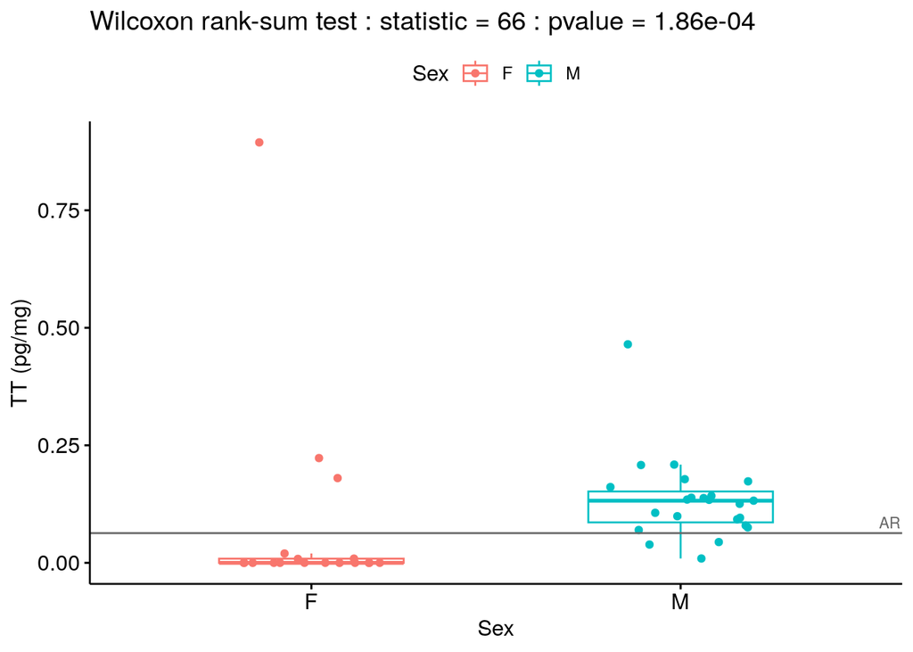

```r
# --- TT, outlier-removed, linear scale ---
p_tt_lin <- ggboxplot(clean_targeted, x = "Sex", y = "`TT (pg/mg)`",
                      color = "Sex", width = 0.5,
                      ylab = "TT (pg/mg)", xlab = "Sex",
                      add = "jitter") +
  labs(title = paste(clean_tt_test_type,
                     ": statistic =", round(clean_tt_test_statistic, 2),
                     ": pvalue =", formatC(clean_tt_p_value, format = "e", digits = 2)))

p_tt_lin <- add_kd_lines(p_tt_lin, "TT", lt = "solid")
print(p_tt_lin)
```

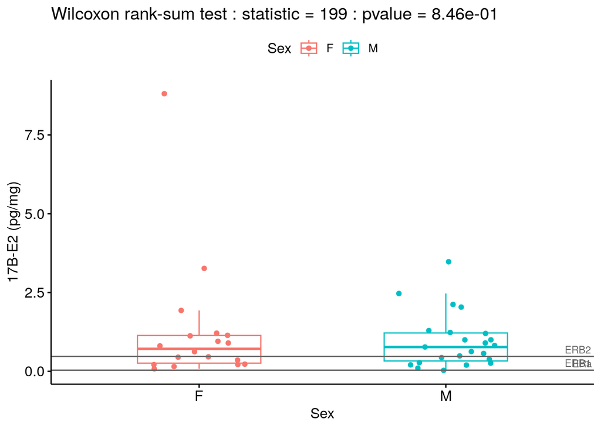

```r
ggsave("clean_tt_statistics_sex_kd.svg", plot = p_tt_lin, path = svg_path)
ggsave("clean_tt_statistics_sex_kd.png", plot = p_tt_lin, path = svg_path, dpi = 300)
# --- E2, outlier-removed, linear scale ---
p_e2_lin <- ggboxplot(clean_targeted, x = "Sex", y = "`17B-E2 (pg/mg)`",
                      color = "Sex", width = 0.5,
                      ylab = "17B-E2 (pg/mg)", xlab = "Sex",
                      add = "jitter") +
  labs(title = paste(clean_e2_test_type,
                     ": statistic =", round(clean_e2_test_statistic, 2),
                     ": pvalue =", formatC(clean_e2_p_value, format = "e", digits = 2)))

p_e2_lin <- add_kd_lines(p_e2_lin, "E2", lt = "solid")
print(p_e2_lin)
```

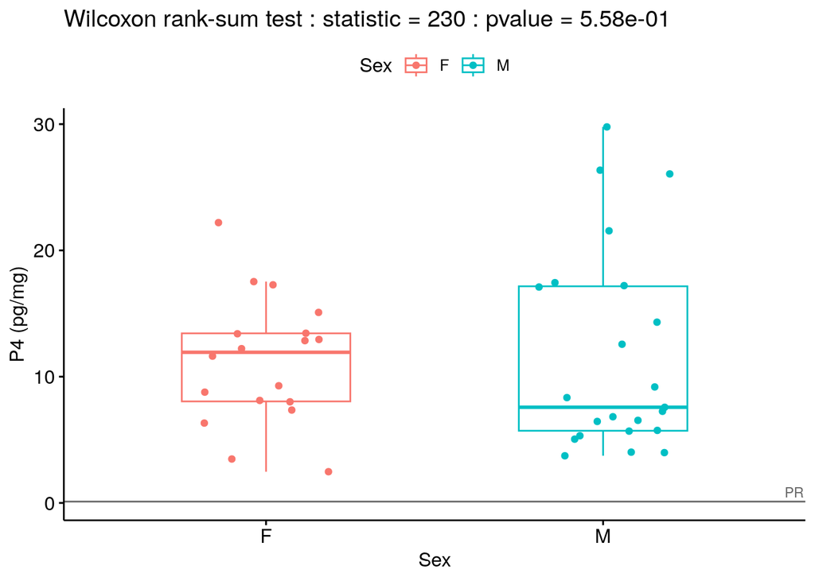

```r
ggsave("clean_e2_statistics_sex_kd.svg", plot = p_e2_lin, path = svg_path)
ggsave("clean_e2_statistics_sex_kd.png", plot = p_e2_lin, path = svg_path, dpi = 300)
# --- P4, outlier-removed, linear scale ---
p_p4_lin <- ggboxplot(clean_targeted, x = "Sex", y = "`P4 (pg/mg)`",
                      color = "Sex", width = 0.5,
                      ylab = "P4 (pg/mg)", xlab = "Sex",
                      add = "jitter") +
  labs(title = paste(clean_p4_test_type,
                     ": statistic =", round(clean_p4_test_statistic, 2),
                     ": pvalue =", formatC(clean_p4_p_value, format = "e", digits = 2)))

p_p4_lin <- add_kd_lines(p_p4_lin, "P4", lt = "solid")
print(p_p4_lin)
```

```r
ggsave("clean_p4_statistics_sex_kd.svg", plot = p_p4_lin, path = svg_path)
ggsave("clean_p4_statistics_sex_kd.png", plot = p_p4_lin, path = svg_path, dpi = 300)
```

### Log10 axis

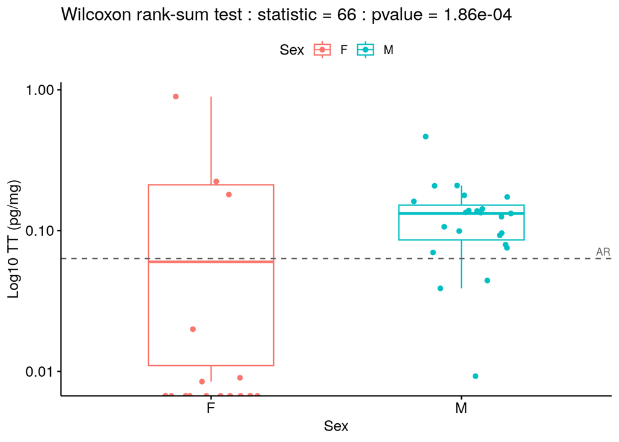

```r
# --- TT, outlier-removed, log scale ---
p_tt <- ggboxplot(clean_targeted, x = "Sex", y = "`TT (pg/mg)`",
                  color = "Sex", width = 0.5,
                  ylab = "Log10 TT (pg/mg)", xlab = "Sex",
                  add = "jitter") +
  scale_y_log10() +
  labs(title = paste(clean_tt_test_type,
                     ": statistic =", round(clean_tt_test_statistic, 2),
                     ": pvalue =", formatC(clean_tt_p_value, format = "e", digits = 2)))

p_tt <- add_kd_lines(p_tt, "TT")
print(p_tt)
```

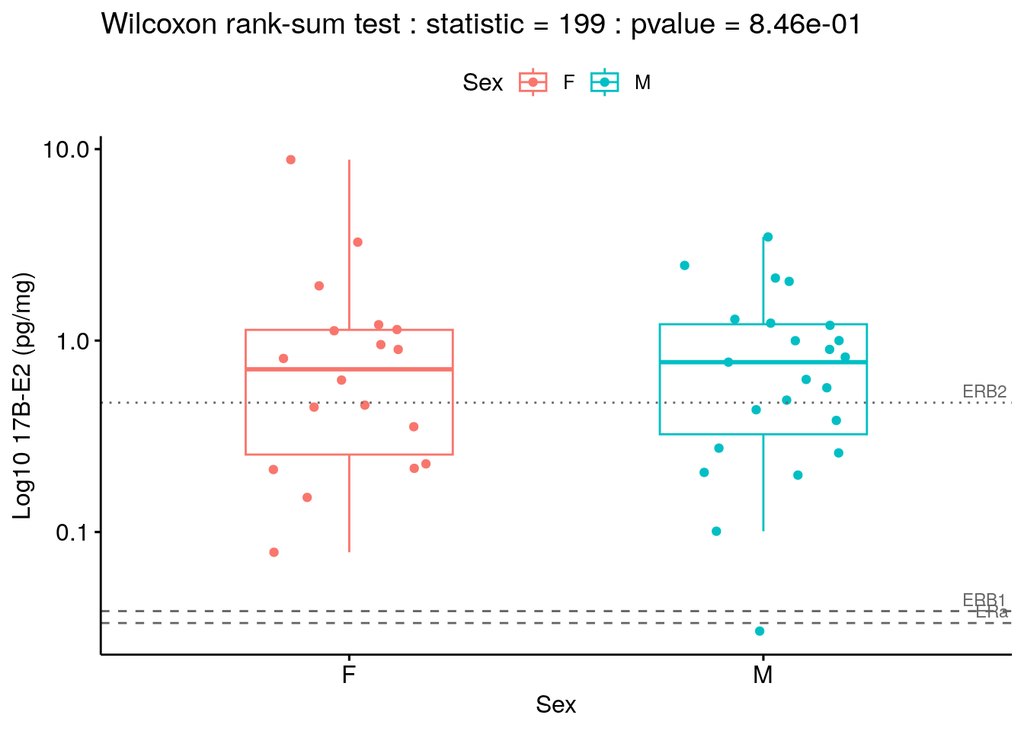

```r
ggsave("log_clean_tt_statistics_sex_kd.svg", plot = p_tt, path = svg_path)
ggsave("log_clean_tt_statistics_sex_kd.png", plot = p_tt, path = svg_path, dpi = 300)
# --- E2, outlier-removed, log scale ---
p_e2 <- ggboxplot(clean_targeted, x = "Sex", y = "`17B-E2 (pg/mg)`",
                  color = "Sex", width = 0.5,
                  ylab = "Log10 17B-E2 (pg/mg)", xlab = "Sex",
                  add = "jitter") +
  scale_y_log10() +
  labs(title = paste(clean_e2_test_type,
                     ": statistic =", round(clean_e2_test_statistic, 2),
                     ": pvalue =", formatC(clean_e2_p_value, format = "e", digits = 2)))

p_e2 <- add_kd_lines(p_e2, "E2")
print(p_e2)
```

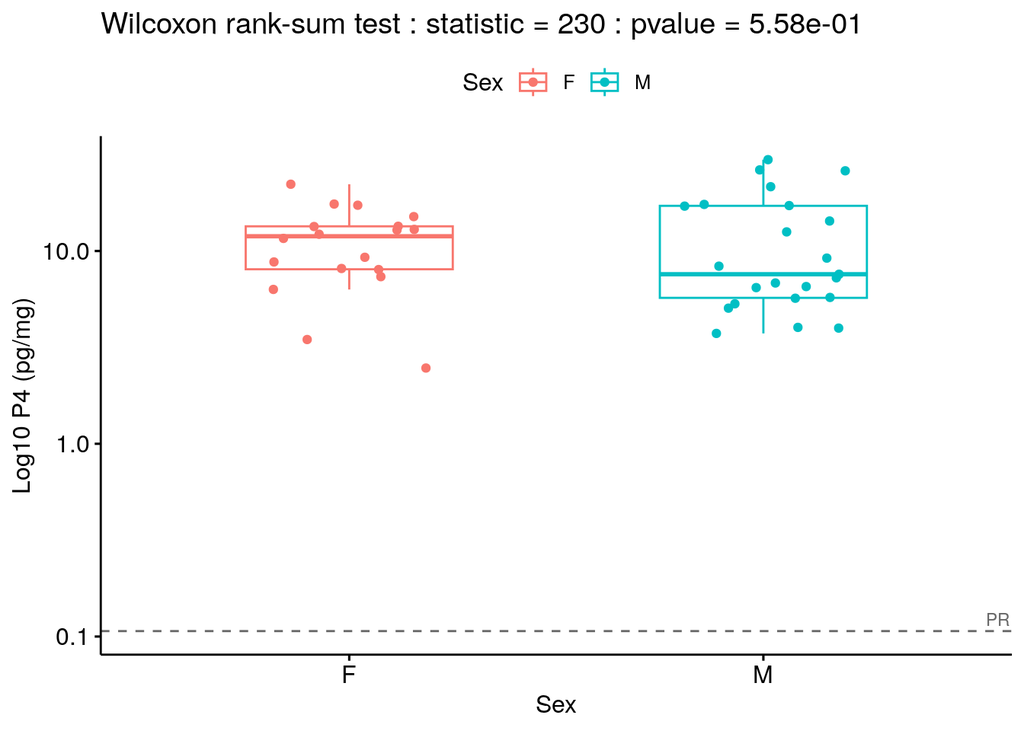

```r
ggsave("log_clean_e2_statistics_sex_kd.svg", plot = p_e2, path = svg_path)
ggsave("log_clean_e2_statistics_sex_kd.png", plot = p_e2, path = svg_path, dpi = 300)
# --- P4, outlier-removed, log scale ---
p_p4 <- ggboxplot(clean_targeted, x = "Sex", y = "`P4 (pg/mg)`",
                  color = "Sex", width = 0.5,
                  ylab = "Log10 P4 (pg/mg)", xlab = "Sex",
                  add = "jitter") +
  scale_y_log10() +
  labs(title = paste(clean_p4_test_type,
                     ": statistic =", round(clean_p4_test_statistic, 2),
                     ": pvalue =", formatC(clean_p4_p_value, format = "e", digits = 2)))

p_p4 <- add_kd_lines(p_p4, "P4")
print(p_p4)
```

```r
ggsave("log_clean_p4_statistics_sex_kd.svg", plot = p_p4, path = svg_path)
ggsave("log_clean_p4_statistics_sex_kd.png", plot = p_p4, path = svg_path, dpi = 300)
```

## Applying to the literature-comparison panels

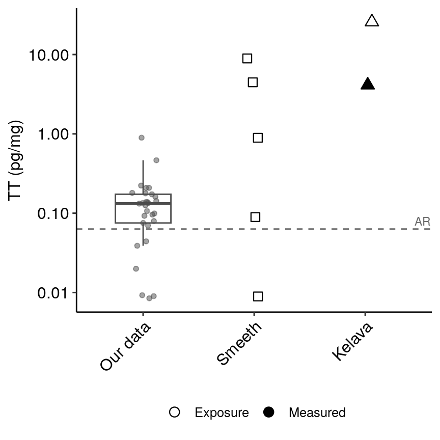

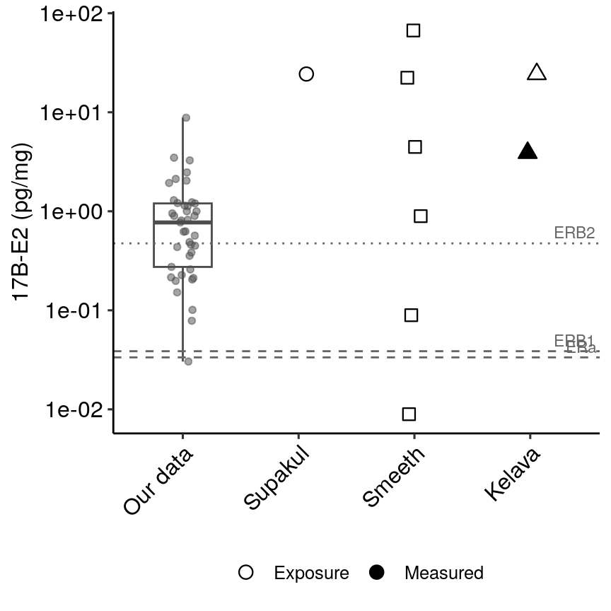

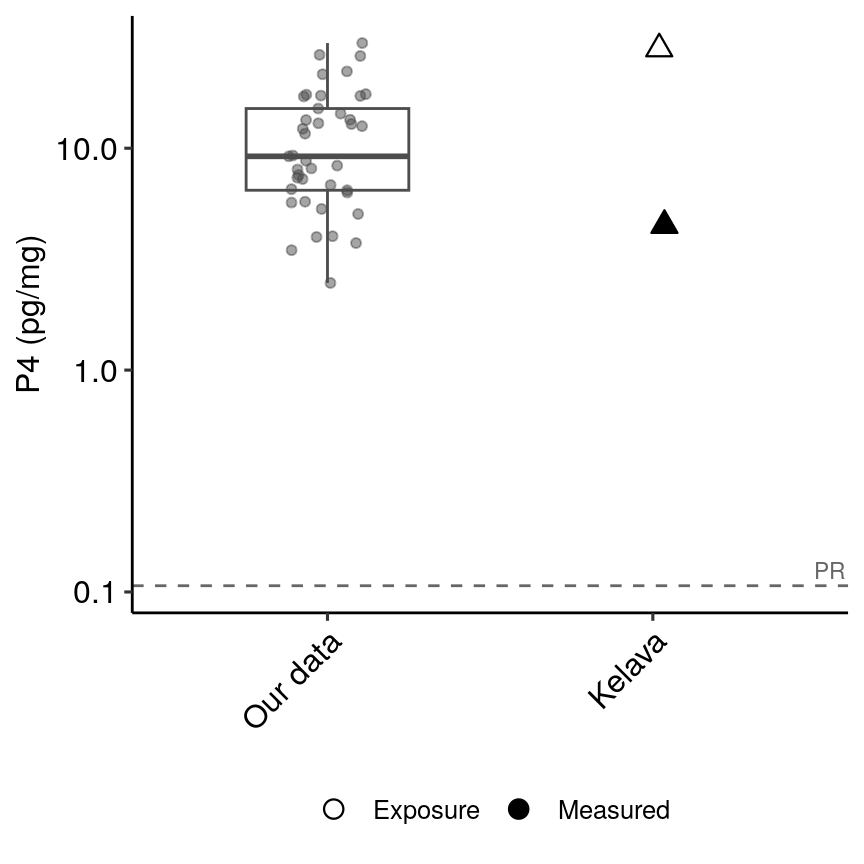

```r
combined_plots_kd <- purrr::imap(combined_plots, ~add_kd_lines(.x, .y))
for (h in names(combined_plots_kd)) {
  print(combined_plots_kd[[h]])
  ggsave(paste0("lit_", tolower(h), "_combined_kd.svg"),
         plot = combined_plots_kd[[h]], path = svg_path,
         width = 4.5, height = 4.5)
  ggsave(paste0("lit_", tolower(h), "_combined_kd.png"),
         plot = combined_plots_kd[[h]], path = svg_path,
         width = 4.5, height = 4.5, dpi = 300)
}
```

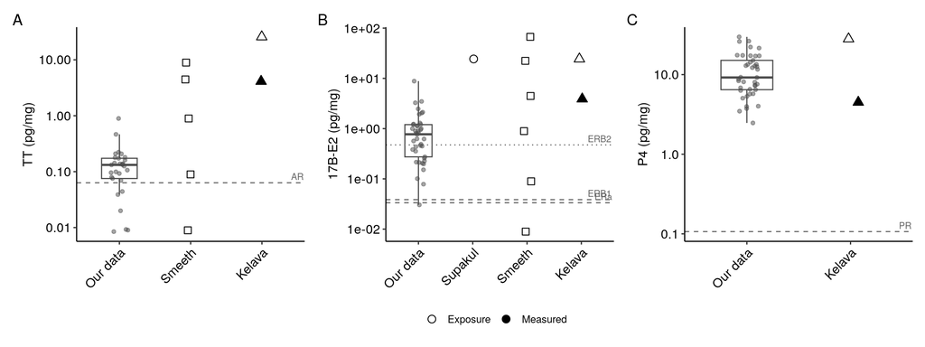

```r
lit_grid_kd <- (combined_plots_kd$TT | combined_plots_kd$E2 | combined_plots_kd$P4) +
  plot_layout(guides = "collect") +
  plot_annotation(tag_levels = "A") &
  theme(legend.position = "bottom")

print(lit_grid_kd)
```

```r
ggsave("lit_all_hormones_combined_kd.svg", plot = lit_grid_kd, path = svg_path,
       width = 12, height = 4.5)
ggsave("lit_all_hormones_combined_kd.png", plot = lit_grid_kd, path = svg_path,
       width = 12, height = 4.5, dpi = 300)
```

## Fold change over Kd

Summarises how far measured concentrations sit above the binding threshold.

```r
kd_fold <- our_hormones %>%
  group_by(hormone) %>%
  summarise(median_pg_mg = median(value, na.rm = TRUE),
            max_pg_mg    = max(value, na.rm = TRUE),
            .groups = "drop") %>%
  left_join(dplyr::select(kd_receptors, hormone, receptor, kd_pg_mg), by = "hormone") %>%
  mutate(fold_median = median_pg_mg / kd_pg_mg,
         fold_max    = max_pg_mg / kd_pg_mg,
         across(c(median_pg_mg, max_pg_mg, kd_pg_mg), ~round(.x, 4)),
         across(c(fold_median, fold_max), ~round(.x, 1)))

kable(kd_fold, caption = "Measured concentration relative to receptor Kd")
```

Measured concentration relative to receptor Kd

| hormone | median_pg_mg | max_pg_mg | receptor | kd_pg_mg | fold_median | fold_max |
| --- | --- | --- | --- | --- | --- | --- |
| TT | 0.0795 | 0.8943 | AR | 0.0632 | 1.3 | 14.1 |
| E2 | 0.7712 | 8.8078 | ERa | 0.0335 | 23.0 | 263.1 |
| E2 | 0.7712 | 8.8078 | ERB1 | 0.0386 | 20.0 | 228.0 |
| E2 | 0.7712 | 8.8078 | ERB2 | 0.4738 | 1.6 | 18.6 |
| P4 | 9.1948 | 29.7806 | PR | 0.1067 | 86.2 | 279.1 |

```r
write.csv(kd_fold, file.path(csv_path, "hormone_kd_fold.csv"),
          row.names = FALSE)
```

# AI Assistance Disclosure

Code in this script was developed with assistance from Claude (Anthropic). All AI-generated code was reviewed, validated, and adapted by the author.